# Car Prices

Example of Report

Lídia Montero

2022

```r
rm(list=ls())
load("Sample_raw.Rdata")
par(mfrow=c(1,1))
```

# Data preparation

First, the data was imported and sampled. The result is saved as “Sample_raw.Rdata” and imported.

## Variable Analysis

On each variable of this data, descriptive analysis is performed, a data quality report made and imputation and profiling accounted for.

### variable 1: model

Model is a nominal variable without missing values. However, it has a lot of levels (89) with a few very sparsly populated ones, such that converting it to a factor is not feasable.

```r
summary(df$model)
```

```
##    Length     Class      Mode
##      5000 character character
```

```r
table(df$model)
```

```
##
##         1 Series         2 Series         3 Series         4 Series
##              206              141              240               90
##         5 Series         6 Series         7 Series         8 Series
##              108               11               12                5
##          A Class               A1               A3               A4
##              277              151              208              137
##               A5               A6               A7               A8
##               62               86                7               14
##           Amarok           Arteon          B Class           Beetle
##               15               24               55                8
##          C Class       Caddy Life  Caddy Maxi Life       California
##              354                2               10                1
##        Caravelle               CC         CL Class        CLA Class
##               13               13               34                8
##        CLS Class          E Class              Eos              Fox
##               37              184                2                1
##          G Class         GL Class        GLA Class        GLC Class
##                3               15               84              102
##        GLE Class        GLS Class             Golf          Golf SV
##               42                9              497               21
##               i3               i8            Jetta          M Class
##                6                3                3                8
##               M2               M3               M4               M5
##                3                4               15                5
##           Passat             Polo               Q2               Q3
##               80              333               87              135
##               Q5               Q7               Q8              RS3
##               95               40                1                1
##              RS4              RS5              RS6          S Class
##                3                2                3               23
##               S3               S4               S5               S8
##                1                1                1                1
##         Scirocco           Sharan          Shuttle         SL CLASS
##               25               33                3               27
##              SLK              SQ5              SQ7          T-Cross
##               13                4                1               20
##            T-Roc           Tiguan  Tiguan Allspace          Touareg
##               70              180                9               39
##           Touran               TT               Up          V Class
##               40               34               79               26
##          X-CLASS               X1               X2               X3
##                7               74               29               56
##               X4               X5               X6               X7
##               25               40               12                5
##               Z4
##                6
```

```r
sum(is.na(df$model))
```

```
## [1] 0
```

```r
df$model[1:5]
```

```
## [1] " A3" " A3" " Q5" " A4" " Q3"
```

### variable 2: year

```r
summary(df$year)
```

```
##    Min. 1st Qu.  Median    Mean 3rd Qu.    Max.
##    2000    2016    2017    2017    2019    2020
```

```r
sum(is.na(df$year))
```

```
## [1] 0
```

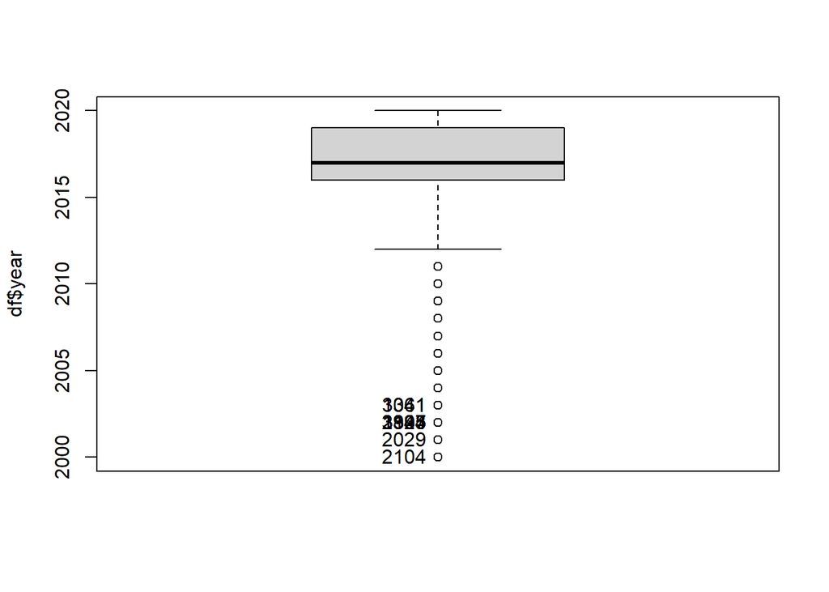

```
##  [1] 2104 2029 1837 2105 3325 3343 3344 3995 1061 3341
```

```r
Boxplot(df$year)
```

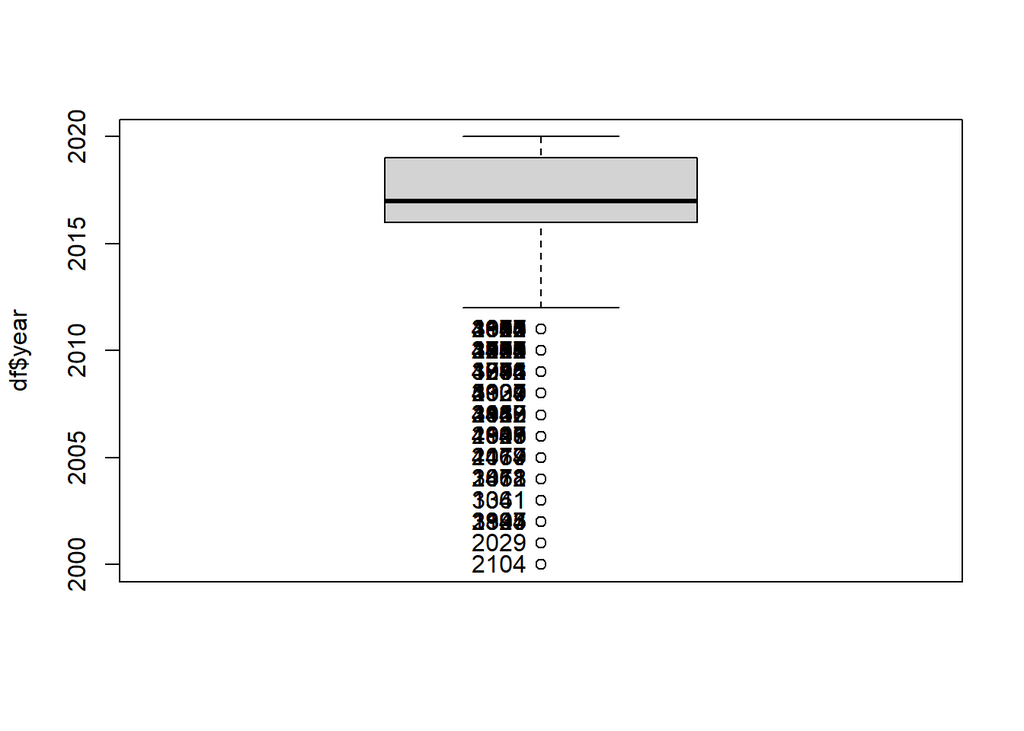

```
## [1] 80
```

```r
length(Boxplot(df$year, id = list(n=Inf)))
```

```r
sevout = (quantile(df$year,0.25)-(3*((quantile(df$year,0.75)-quantile(df$year,0.25)))))
length(which(df$year < sevout))
```

```
## [1] 25
```

```r
df$n.age = max(df$year)-(df$year)

df$f.age <- ifelse(df$n.age <= 1, 1, ifelse(df$n.age > 1 & df$n.age <= 3, 2, ifelse(df$n.age > 3 & df$n.age <= 4, 3, ifelse(df$n.age > 4, 4,0))))
df$f.age <- factor(df$f.age, labels=c("LowAge","LowMidAge","HighMidAge","HighAge"), order = T, levels=c(1,2,3,4))
table(df$f.age)
```

```
##
##     LowAge  LowMidAge HighMidAge    HighAge
##       1938       1426        798        838
```

### variable 3: price

This is a continuous ratio variable. The data is not normally distributed, but this fact is further answered in question 1 in the next section of this document. Again a histogram is used to visualize the data. It contains no missing values thus imputation is not needed. The price variable contains 207 outliers (out of which 108 severe), all on the higher end of the spectrum. We create an additional ordinal price factor “f.price” to create a discretisation according to the quartiles.

```r
summary(df$price)
```

```
##    Min. 1st Qu.  Median    Mean 3rd Qu.    Max.
##    1275   14000   19799   21602   26000  149948
```

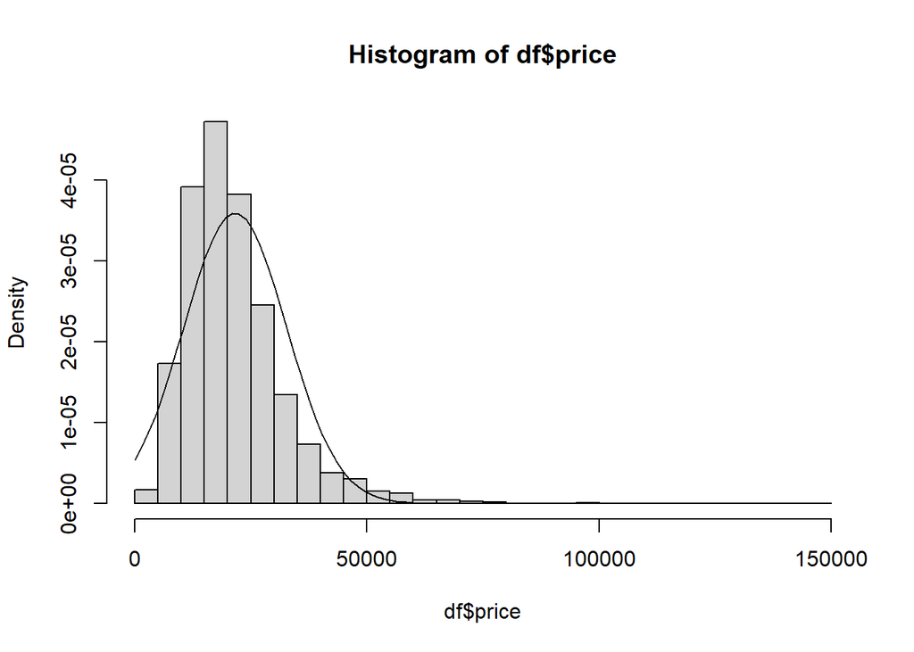

```r
hist(df$price, breaks = 30, freq = F)
curve(dnorm(x, mean(df$price), sd(df$price)), add = T)
```

```r
shapiro.test(df$price)
```

```
##
##  Shapiro-Wilk normality test
##
## data:  df$price
## W = 0.86882, p-value < 2.2e-16
```

```r
sum(is.na(df$price))
```

```
## [1] 0
```

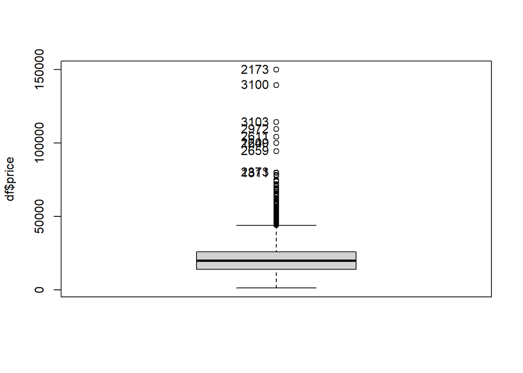

```
##  [1] 2173 3100 3103 2972 2611 1609 2240 2659 2373 1811
```

```r
Boxplot(df$price)
```

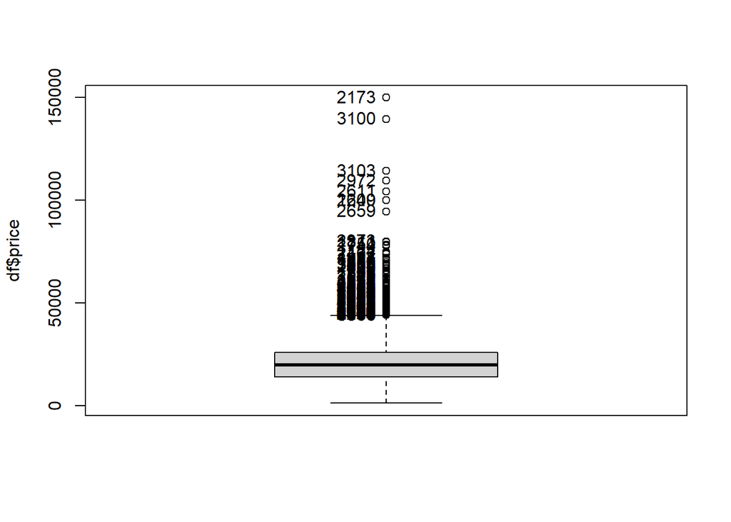

```
## [1] 207
```

```r
length(Boxplot(df$price, id = list(n=Inf)))
```

```r
sevout_price = (quantile(df$price,0.25)+(3*((quantile(df$price,0.75)-quantile(df$price,0.25)))))
length(which(df$price > sevout_price))
```

```
## [1] 108
```

```r
df$f.price <- ifelse(df$price <= 14000, 1, ifelse(df$price > 14000 & df$price <= 19799, 2, ifelse(df$price > 19799 & df$price <= 26000, 3, ifelse(df$price > 26000, 4,0))))
df$f.price <- factor(df$f.price, labels=c("LowPrice","LowMidPrice","HighMidPrice","HighPrice"), order = T, levels=c(1,2,3,4))
table(df$f.price)
```

```
##
##     LowPrice  LowMidPrice HighMidPrice    HighPrice
##         1257         1244         1258         1241
```

### variable 4: transmission

This is a Nominal variable (with three levels) and is thus converted to the factor type. It is visualized by a bar plot, in which it is clear that all levels are well represented. Therefore, no outliers are present. The variable contains no missing values thus imputation is not needed.

```r
summary(df$transmission)
```

```
##    Length     Class      Mode
##      5000 character character
```

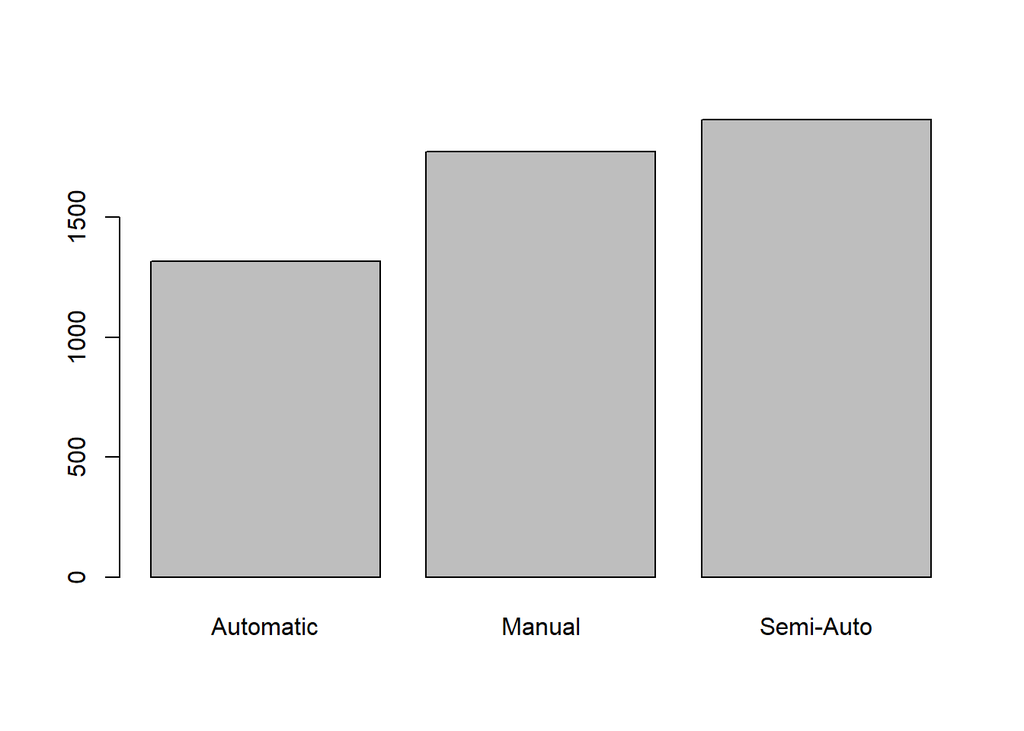

```r
df$transmission = factor(df$transmission)
plot(df$transmission)
```

```r
sum(is.na(df$transmission))
```

```
## [1] 0
```

### variable 5: mileage

This is a continuous ratio variable. The data does not look normally distributed, which is confirmed by the near-null p-value of the shapiro normallity test. Again a histogram is used to visualize the data. The variable contains no missing values thus imputation is not needed. It contains 188 outliers (out of which 98 severe), all on the higher end of the spectrum. We create an additional ordinal mileage factor “f.mileage” to create a discretisation according to the quartiles.

```r
summary(df$mileage)
```

```
##    Min. 1st Qu.  Median    Mean 3rd Qu.    Max.
##       1    5728   16395   23042   33102  212000
```

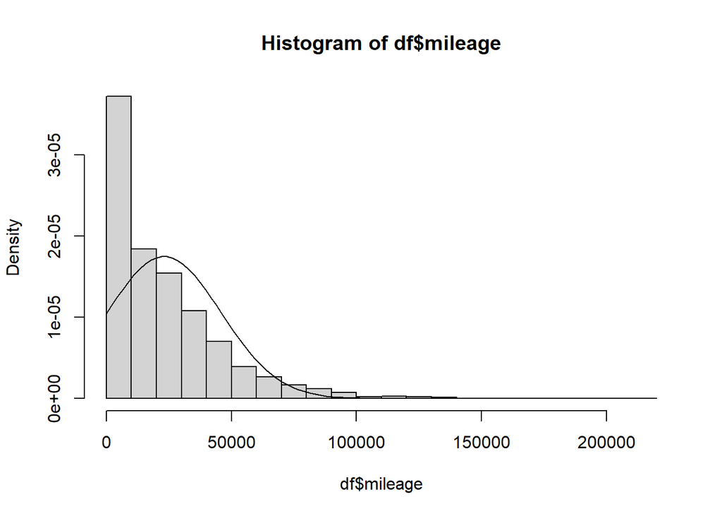

```r
hist(df$mileage, breaks = 30, freq = F)
curve(dnorm(x, mean(df$mileage), sd(df$mileage)), add = T)
```

```r
shapiro.test(df$mileage)
```

```
##
##  Shapiro-Wilk normality test
##
## data:  df$mileage
## W = 0.83769, p-value < 2.2e-16
```

```r
sum(is.na(df$mileage))
```

```
## [1] 0
```

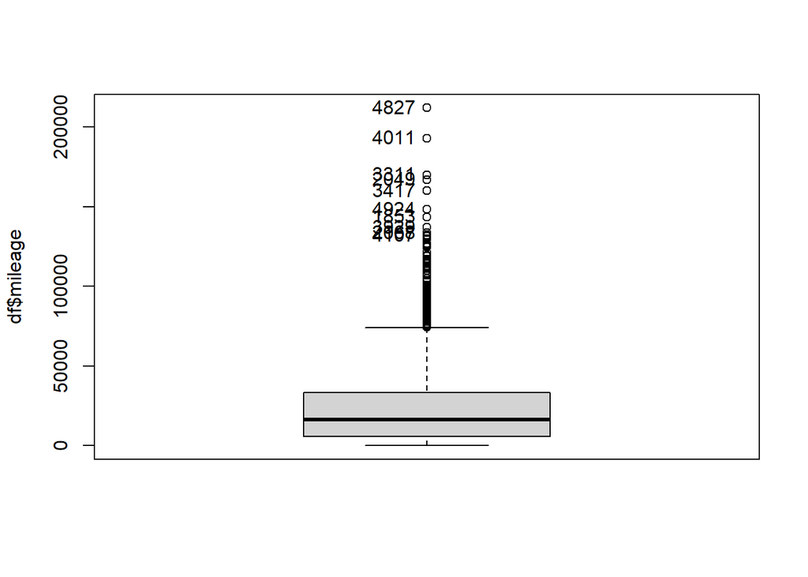

```
##  [1] 4827 4011 3311 2049 3417 4924 1853 3929 2068 4107
```

```r
Boxplot(df$mileage)
```

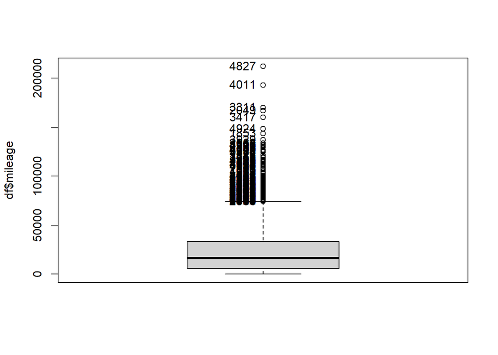

```
## [1] 188
```

```r
length(Boxplot(df$mileage, id = list(n=Inf)))
```

```r
sevout_mileage = (quantile(df$mileage,0.25)+(3*((quantile(df$mileage,0.75)-quantile(df$mileage,0.25)))))
length(which(df$mileage > sevout_mileage))
```

```
## [1] 98
```

```r
df$f.mileage <- ifelse(df$mileage <= 5728, 1, ifelse(df$mileage > 5728 & df$mileage <= 16395, 2, ifelse(df$mileage > 16395 & df$mileage <= 33102, 3, ifelse(df$mileage > 33102, 4,0))))
df$f.mileage <- factor(df$f.mileage,labels=c("LowMileage","LowMidMileage","HighMidMileage","HighMileage"), order = T, levels=c(1,2,3,4))
table(df$f.mileage)
```

```
##
##     LowMileage  LowMidMileage HighMidMileage    HighMileage
##           1250           1250           1250           1250
```

### variable 6: fuelType

This is a nominal variable with 5 levels in which ‘electric’, ‘hybrid’ and ‘other’ only combine for less then 2% of the instances combined, such that these are all collapsed into the ‘other’ level. The variable contains no missing values thus imputation is not needed. A bar plot is used to plot the variable.

```r
summary(df$fuelType)
```

```
##    Length     Class      Mode
##      5000 character character
```

```r
elec_idx <- which(df$fuelType == 'Electric')
prop.table(table(df$fuelType))
```

```
##
##   Diesel Electric   Hybrid    Other   Petrol
##   0.5548   0.0002   0.0122   0.0036   0.4292
```

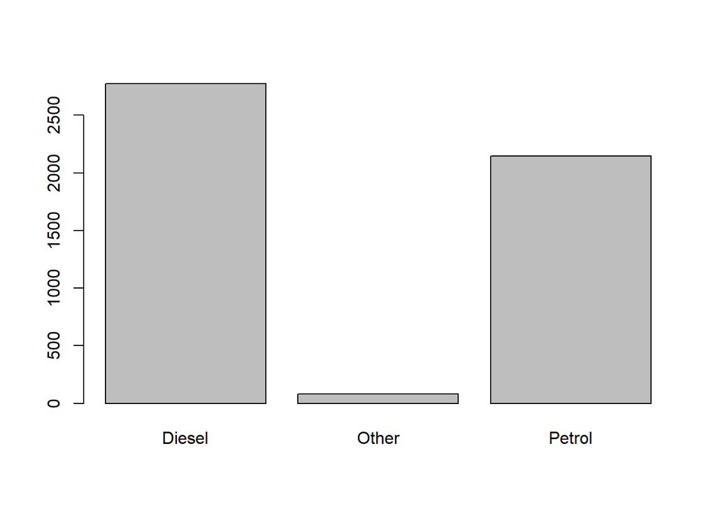

```r
df$fuelType[which(df$fuelType == 'Hybrid')] = 'Other'
df$fuelType[which(df$fuelType == 'Electric')] = 'Other'
df$fuelType = factor(df$fuelType)

plot(df$fuelType)
```

### variable 7: tax

This is a continuous ratio variable. The data does not look normally distributed, which is confirmed by the near-null p-value of the shapiro normallity test. Again a histogram is used to visualize the data. The variable contains no missing values thus imputation is not needed. It contains 1422 outliers (out of which all severe), on both sides of the spectrum. We create an additional ordinal tax factor “f.tax” to create a discretisation according to the quartiles.

```r
summary(df$tax)
```

```
##    Min. 1st Qu.  Median    Mean 3rd Qu.    Max.
##     0.0   125.0   145.0   124.9   145.0   570.0
```

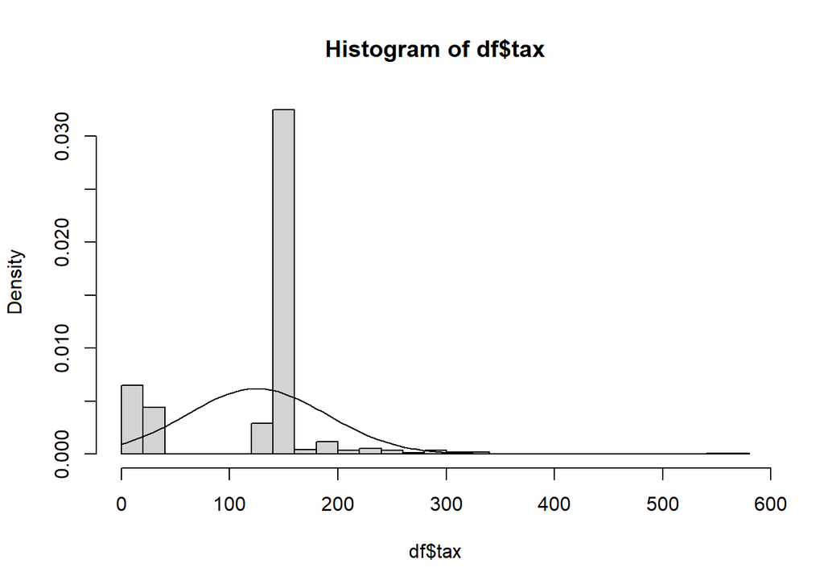

```r
hist(df$tax, breaks = 30, freq = F)
curve(dnorm(x, mean(df$tax), sd(df$tax)), add = T)
```

```r
shapiro.test(df$tax)
```

```
##
##  Shapiro-Wilk normality test
##
## data:  df$tax
## W = 0.72815, p-value < 2.2e-16
```

```r
sum(is.na(df$tax))
```

```
## [1] 0
```

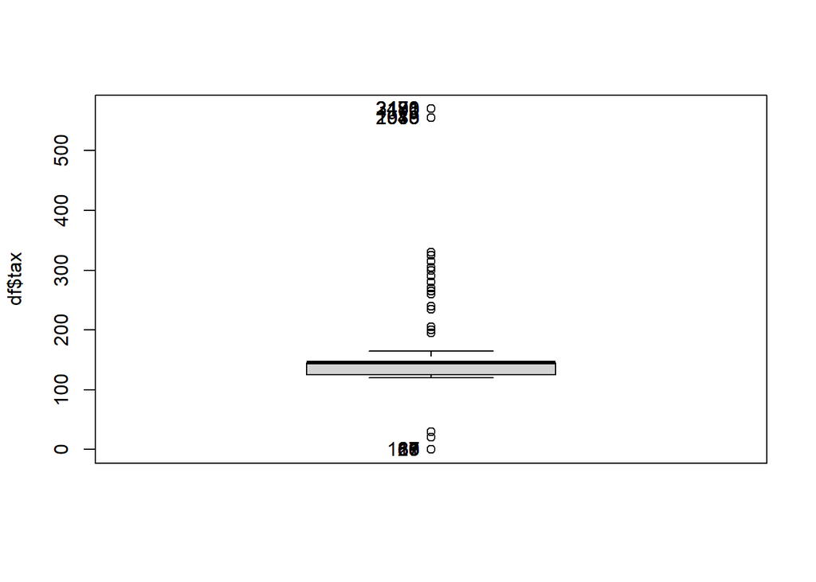

```
##  [1]    7    9   17   21   66   67   85   88   89  136 2173 2180 2191 2198 3430
## [16] 3431  979 1543 2010 2088
```

```r
Boxplot(df$tax)
```

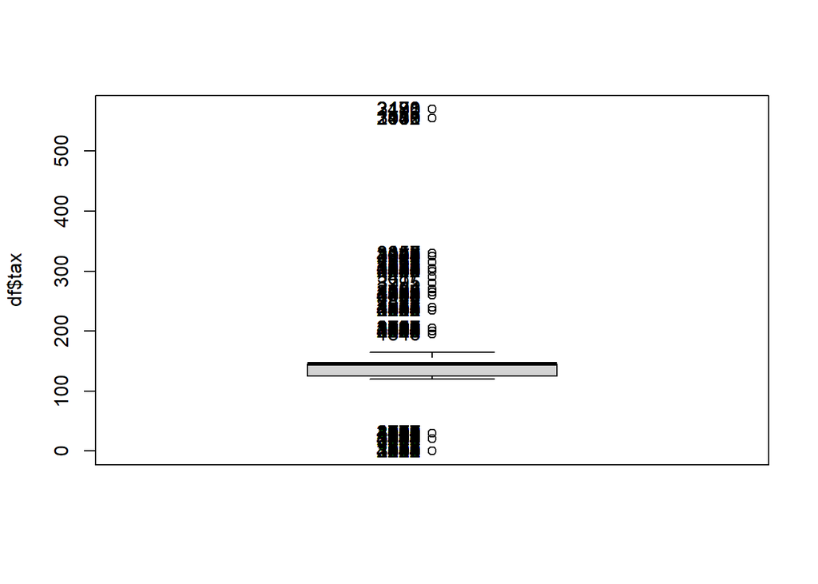

```
## [1] 1422
```

```r
length(Boxplot(df$tax, id = list(n=Inf)))
```

```r
sevout_tax_upp = (quantile(df$tax,0.25)+(3*((quantile(df$tax,0.75)-quantile(df$tax,0.25)))))
sevout_tax_low = (quantile(df$tax,0.25)-(3*((quantile(df$tax,0.75)-quantile(df$tax,0.25)))))
length(which(df$tax > sevout_tax_upp))+length(which(df$tax < sevout_tax_low))
```

```
## [1] 1422
```

```r
df$f.tax <- ifelse(df$tax <= 125, 1, ifelse(df$tax > 125 & df$tax < 145, 2, ifelse(df$tax == 145, 3, ifelse(df$tax > 145, 4,0))))
df$f.tax <- factor(df$f.tax,labels=c("Lowtax","LowMidtax","HighMidtax","Hightax"), order = T, levels=c(1,2,3,4))
table(df$f.tax)
```

```
##
##     Lowtax  LowMidtax HighMidtax    Hightax
##       1349         34       2610       1007
```

### variable 8: mpg

This is a continuous ratio variable. The data does not look normally distributed, which is confirmed by the near-null p-value of the shapiro normallity test. Again a histogram is used to visualize the data. The variable contains no missing values thus imputation is not needed. It contains 56 outliers (out of which 53 severe), all on the high side of the spectrum. We create an additional ordinal mpg factor “f.mpg” to create a discretisation according to the quartiles.

```r
summary(df$mpg)
```

```
##    Min. 1st Qu.  Median    Mean 3rd Qu.    Max.
##   19.50   44.10   52.80   53.96   61.40  470.80
```

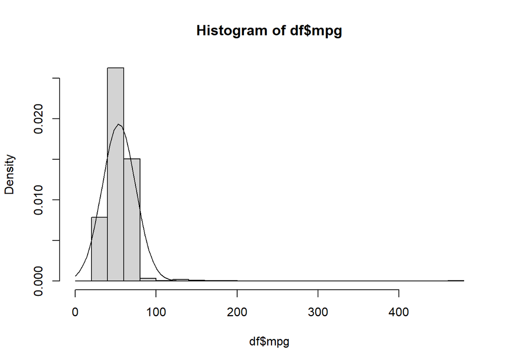

```r
hist(df$mpg, breaks = 30, freq = F)
curve(dnorm(x, mean(df$mpg), sd(df$mpg)), add = T)
```

```r
shapiro.test(df$mpg)
```

```
##
##  Shapiro-Wilk normality test
##
## data:  df$mpg
## W = 0.52394, p-value < 2.2e-16
```

```r
sum(is.na(df$mpg))
```

```
## [1] 0
```

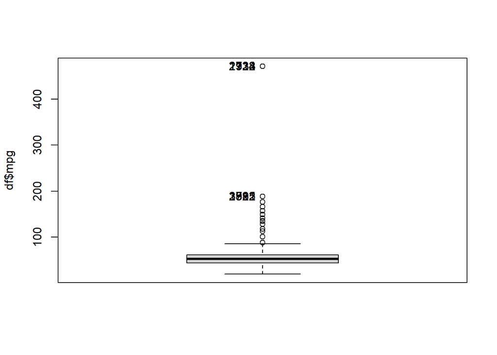

```
##  [1] 1133 1324 1732 1934 2114 2138 1582 2995 3722 3811
```

```r
Boxplot(df$mpg)
```

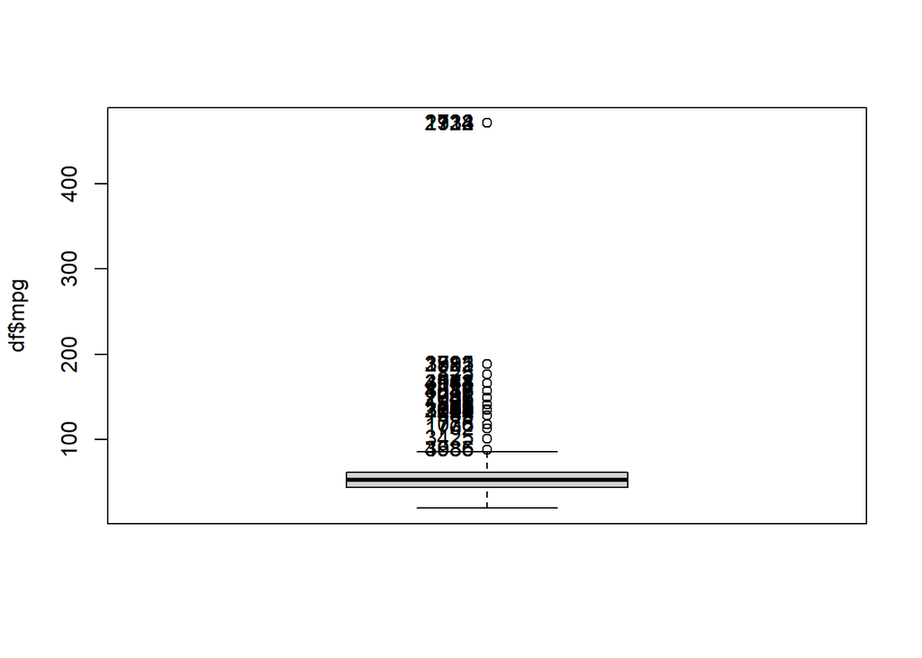

```
## [1] 56
```

```r
length(Boxplot(df$mpg, id = list(n=Inf)))
```

```r
sevout_mpg = (quantile(df$mpg,0.25)+(3*((quantile(df$mpg,0.75)-quantile(df$mpg,0.25)))))
length(which(df$mpg > sevout_mpg))
```

```
## [1] 53
```

```r
df$f.mpg <- ifelse(df$mpg <= 44.1, 1, ifelse(df$mpg > 44.1 & df$mpg <= 52.8, 2, ifelse(df$mpg > 52.8 & df$mpg <= 61.4, 3, ifelse(df$mpg > 61.4, 4,0))))
df$f.mpg <- factor(df$f.mpg,labels=c("Lowmpg","LowMidmpg","HighMidmpg","Highmpg"), order = T, levels=c(1,2,3,4))
table(df$f.mpg)
```

```
##
##     Lowmpg  LowMidmpg HighMidmpg    Highmpg
##       1257       1243       1342       1158
```

### variable 9: engineSize

This is an interval variable. It contains 673 outliers, out of which 55 severe. There are 15 instances of cars without enginesize which seems like missing values. As it was stated in the data description, these instance could denote electric fuelTypes, however, after inspecting each case more closely it appeared that only 1 of these truely denotes an electric engine and the others are missing values at random (MAR). As the hybrid and electric fuel types were previously set to other, all engine sizes which have values equal to 0 are set to NA and then imputed using the MICE algorithm (an algorithm using chained equations using k-Nearest-Neighbour and regression techniques), except for the electric fuel type. We create an additional ordinal enginesize factor “f.engineSize” to create a discretisation according to the quartiles.

```r
summary(df$engineSize)
```

```
##    Min. 1st Qu.  Median    Mean 3rd Qu.    Max.
##   0.000   1.500   2.000   1.918   2.000   6.200
```

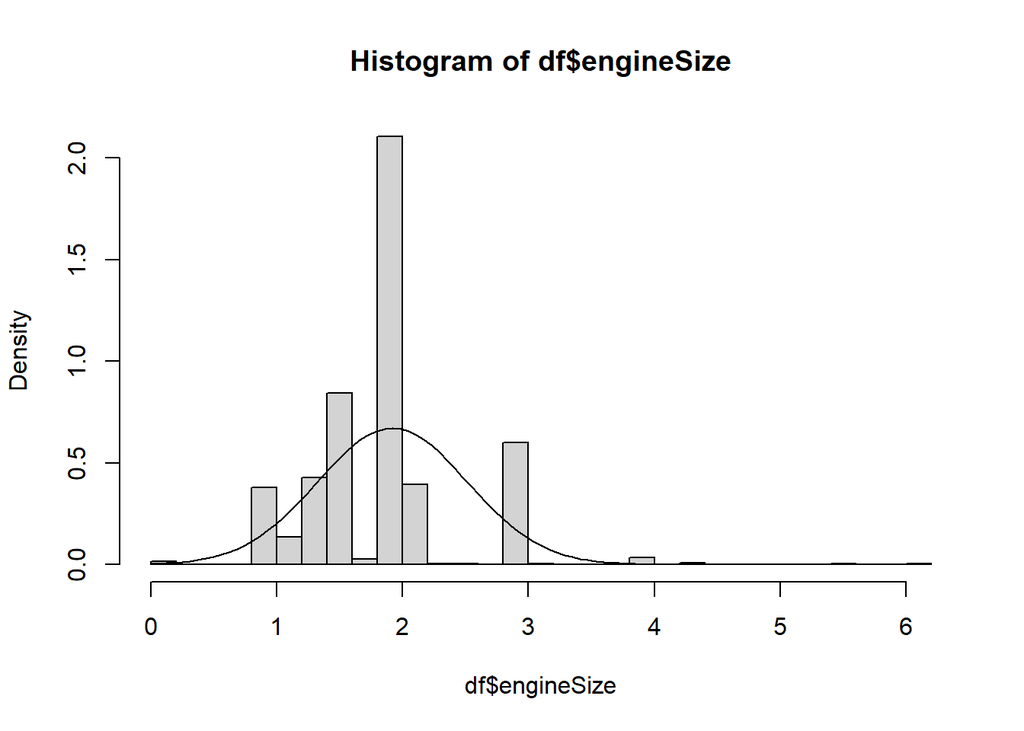

```r
hist(df$engineSize, breaks = 30, freq = F)
curve(dnorm(x, mean(df$engineSize), sd(df$engineSize)), add = T)
```

```r
shapiro.test(df$engineSize)
```

```
##
##  Shapiro-Wilk normality test
##
## data:  df$engineSize
## W = 0.86113, p-value < 2.2e-16
```

```r
sum(is.na(df$engineSize))
```

```
## [1] 0
```

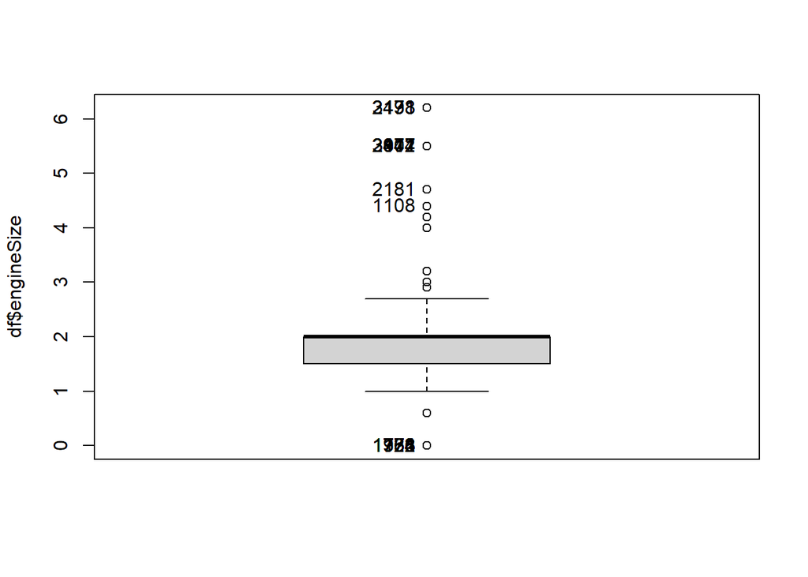

```
##  [1]  758  768  771  772  773  776 1133 1324 1732 1934 2173 2198 3431 2812 2944
## [16] 3077 3111 3401 2181 1108
```

```r
Boxplot(df$engineSize)
```

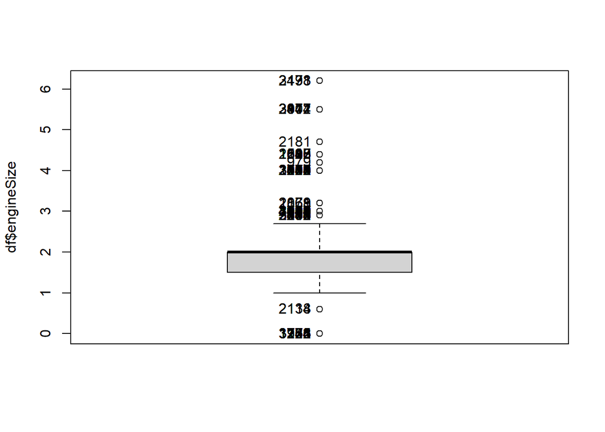

```
## [1] 673
```

```r
length(Boxplot(df$engineSize, id = list(n=Inf)))
```

```r
sevout_engineSize_upp = (quantile(df$engineSize,0.25)+(3*((quantile(df$engineSize,0.75)-quantile(df$engineSize,0.25)))))
sevout_engineSize_down = (quantile(df$engineSize,0.25)-(3*((quantile(df$engineSize,0.75)-quantile(df$engineSize,0.25)))))
length(which(df$engineSize > sevout_engineSize_upp | df$engineSize < sevout_engineSize_down))
```

```
## [1] 55
```

```r
df$engineSize[which(df$engineSize == 0)] = NA
df$engineSize[elec_idx] = 0
require(mice)
options(contrasts = c("contr.treatment", "contr.treatment")) ##set options to contr.treatment as mice can only use lm when options is set to this.
imputation = mice(df, method = 'pmm')
imputation$imp$engineSize
```

```
##         1   2   3   4   5
## 7519  2.0 2.0 1.5 2.0 2.0
## 7599  1.4 1.5 1.4 1.5 1.2
## 7632  1.5 2.0 1.6 2.0 1.5
## 7645  3.0 2.0 3.0 3.0 3.0
## 7660  2.0 2.1 2.0 2.0 3.0
## 7701  1.5 1.6 2.0 1.5 2.0
## 11290 0.6 0.6 0.0 1.0 0.6
## 13021 0.0 1.0 1.0 1.0 0.6
## 16949 1.0 0.6 0.6 1.0 0.6
## 31068 2.0 2.1 2.0 2.0 2.0
## 31069 1.4 1.4 2.0 1.6 1.6
## 31071 2.0 2.0 2.0 2.0 1.4
## 32125 2.1 1.5 2.0 2.0 2.1
## 32189 1.6 2.0 2.1 2.0 1.5
```

```r
df = complete(imputation, 5)
summary(df$engineSize)
```

```
##    Min. 1st Qu.  Median    Mean 3rd Qu.    Max.
##   0.000   1.500   2.000   1.922   2.000   6.200
```

```r
df$f.engineSize <- ifelse(df$engineSize <= 1.5, 1, ifelse(df$engineSize > 1.5 & df$engineSize < 2, 2, ifelse(df$engineSize >= 2 & df$engineSize <= 2, 3, ifelse(df$engineSize > 2, 4,0))))
df$f.engineSize <- factor(df$f.engineSize,labels=c("LowengineSize","LowMidengineSize","HighMidengineSize","HighengineSize"), order = T, levels=c(1,2,3,4))
table(df$f.engineSize)
```

```
##
##     LowengineSize  LowMidengineSize HighMidengineSize    HighengineSize
##              1496               332              2104              1068
```

### variable 10: manufacturer

This is a Nominal variable (with four levels) and is thus converted to the factor type. It is visualized by a bar plot, in which it is clear that all levels are well represented. Therefore, no outliers are present. The variable contains no missing values thus imputation is not needed.

```r
table(df$manufacturer)
```

```
##
##     Audi      BMW Mercedes       VW
##     1075     1096     1308     1521
```

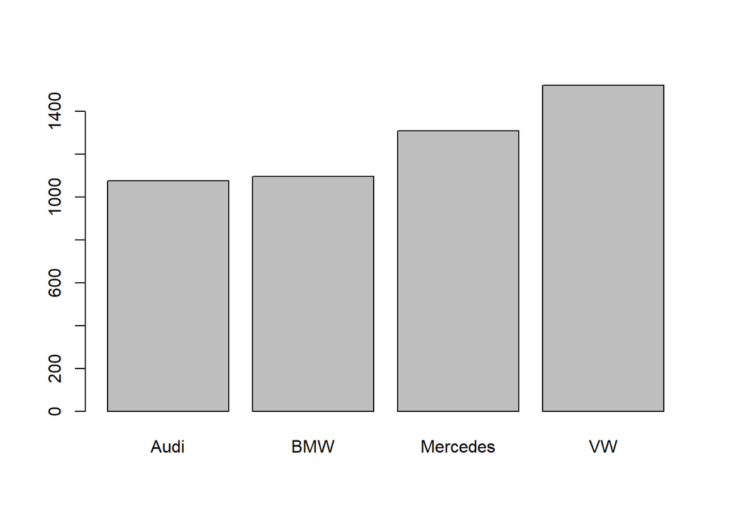

```r
df$manufacturer = factor(df$manufacturer)
plot(df$manufacturer)
```

```r
sum(is.na(df$manufacturer))
```

```
## [1] 0
```

## Data quality report

### Variables

Now that all the variables have been explored, their general quality can be reported on. In terms of missingness, only the engineSize shows missing data and hence, it ranks last in terms of missingness. If we rank the numeric variables in terms of number of outliers, the following list is obtained, starting with the most outliers: Tax, engine size, price, mileage, year and mpg. Combining these two results, it seems like both tax and engine size are the variables containing the most noise in this data set.

### individuals

Now the individuals are investigated. First the number of univariate outliers per individual are counted and added in a new variable called ‘univ_outl_count’. Looking at the 8 individuals with the most univariate outliers (4) it can be concluded that they are all old, highly taxed, low mpg, high engine size and most with a low price and high mileage. A correlation matrix confirms this as it shows a significant negative correlation to the year (so the older the car, the more univ outliers) and a significant positive correlation to both mileage and engine size.

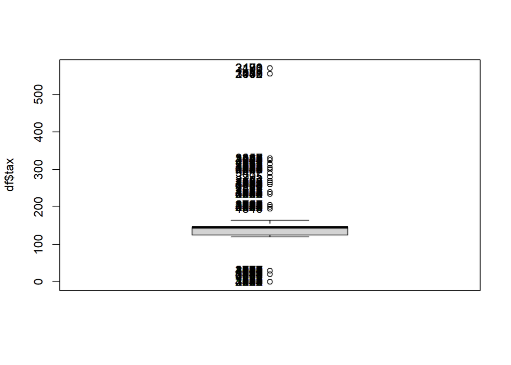

```r
df$univ_outl_count <- 0
df$univ_outl_count[Boxplot(df$tax, id = list(n=Inf))] = df$univ_outl_count[Boxplot(df$tax, id = list(n=Inf))] + 1
```

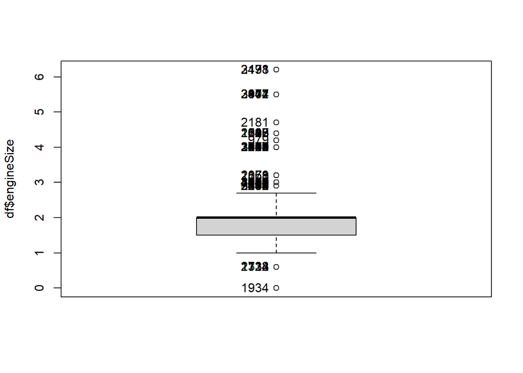

```r
df$univ_outl_count[Boxplot(df$engineSize, id = list(n=Inf))] = df$univ_outl_count[Boxplot(df$engineSize, id = list(n=Inf))] + 1
```

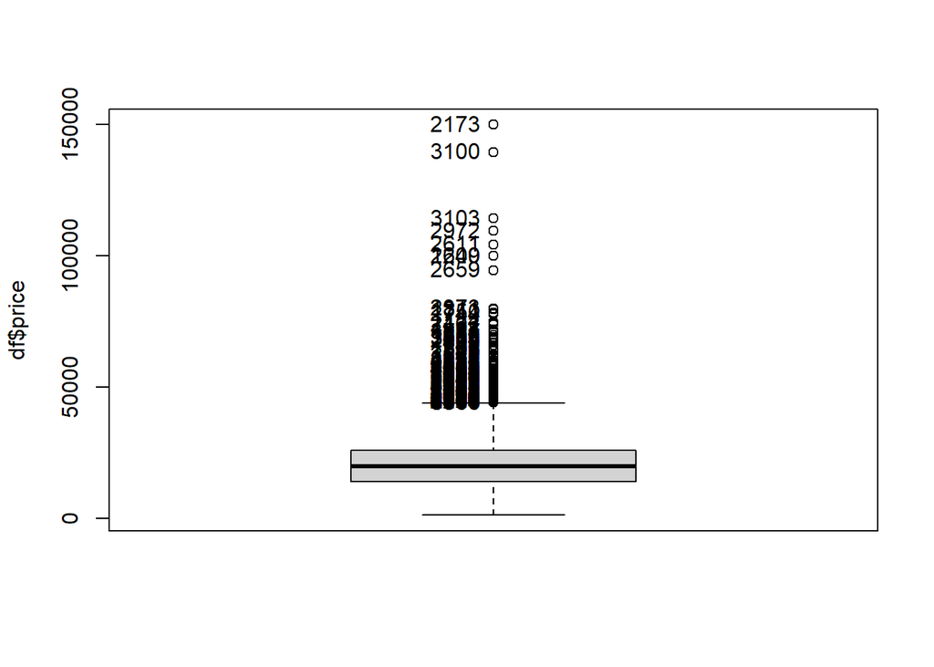

```r
df$univ_outl_count[Boxplot(df$price, id = list(n=Inf))] = df$univ_outl_count[Boxplot(df$price, id = list(n=Inf))] + 1
```

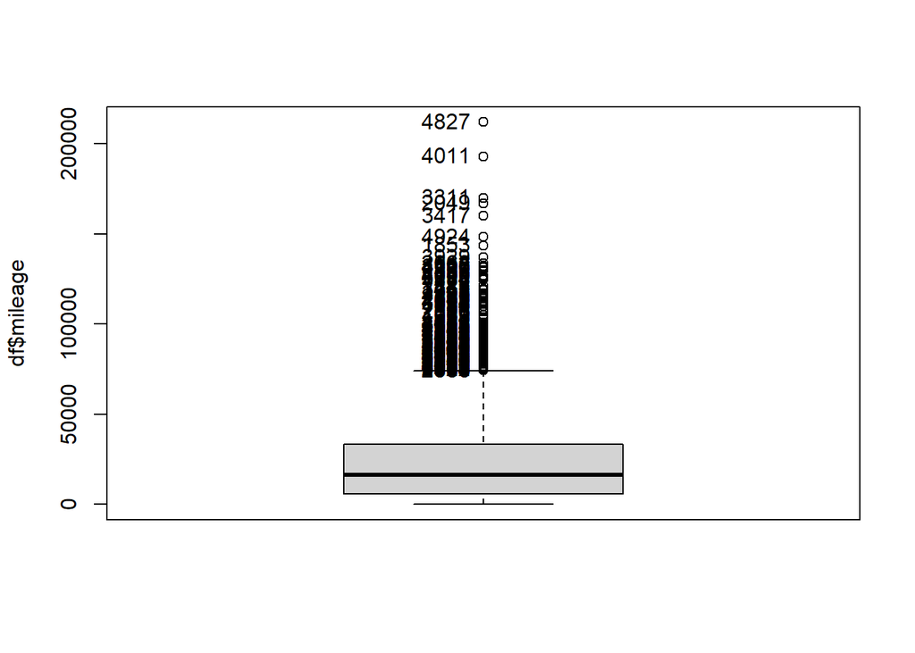

```r
df$univ_outl_count[Boxplot(df$mileage, id = list(n=Inf))] = df$univ_outl_count[Boxplot(df$mileage, id = list(n=Inf))] + 1
```

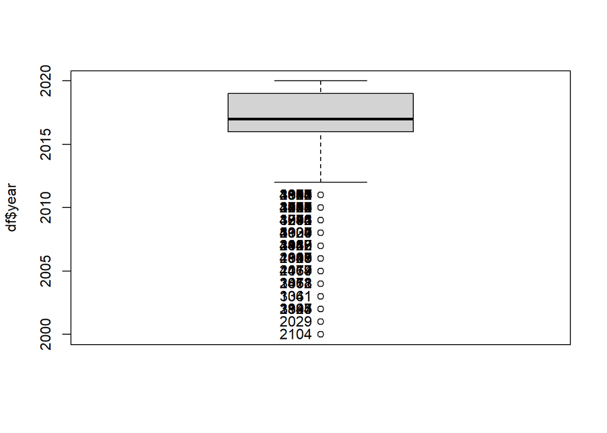

```r
df$univ_outl_count[Boxplot(df$year, id = list(n=Inf))] = df$univ_outl_count[Boxplot(df$year, id = list(n=Inf))] + 1
```

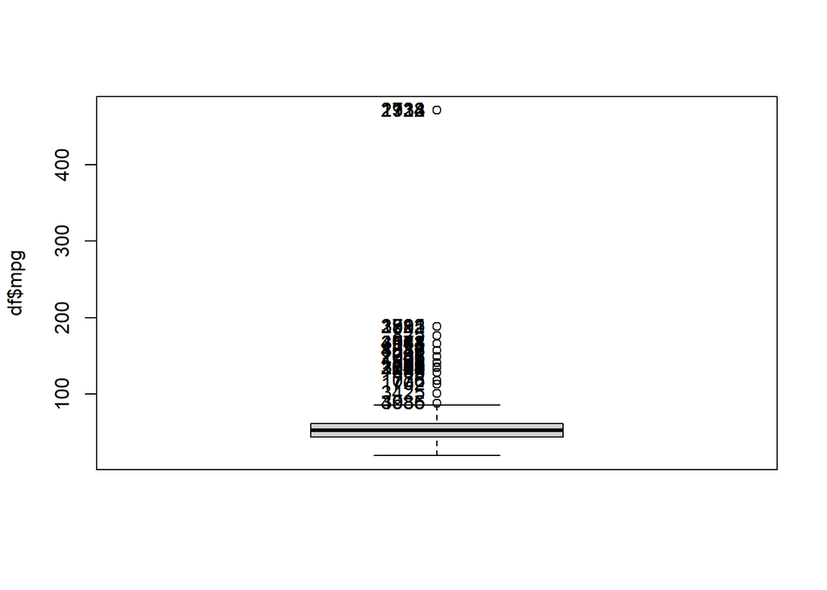

```r
df$univ_outl_count[Boxplot(df$mpg, id = list(n=Inf))] = df$univ_outl_count[Boxplot(df$mpg, id = list(n=Inf))] + 1
```

```r
max(df$univ_outl_count)
```

```
## [1] 4
```

```r
df[which(df$univ_outl_count == 4),]
```

```
##          model year  price transmission mileage fuelType tax  mpg engineSize
## 1014        A4 2005   4990       Manual   87990   Diesel 325 36.7        3.0
## 1023        A8 2006   5595    Automatic  104000   Diesel 325 33.6        3.0
## 2010  6 Series 2006   4999    Automatic  126054   Petrol 555 29.7        3.0
## 2029  3 Series 2001   3050    Automatic   90000   Petrol 325 27.7        3.0
## 2130  3 Series 2008   8790       Manual   85000   Petrol 555 28.5        3.0
## 2169        M3 2005  10999       Manual  115000   Petrol 315 20.8        3.2
## 2173  SL CLASS 2011 149948    Automatic    3000   Petrol 570 21.4        6.2
## 3296   E Class 2009   3995    Automatic  131711   Diesel 300 27.7        3.0
##      manufacturer n.age   f.age   f.price   f.mileage   f.tax  f.mpg
## 1014         Audi    15 HighAge  LowPrice HighMileage Hightax Lowmpg
## 1023         Audi    14 HighAge  LowPrice HighMileage Hightax Lowmpg
## 2010          BMW    14 HighAge  LowPrice HighMileage Hightax Lowmpg
## 2029          BMW    19 HighAge  LowPrice HighMileage Hightax Lowmpg
## 2130          BMW    12 HighAge  LowPrice HighMileage Hightax Lowmpg
## 2169          BMW    15 HighAge  LowPrice HighMileage Hightax Lowmpg
## 2173     Mercedes     9 HighAge HighPrice  LowMileage Hightax Lowmpg
## 3296     Mercedes    11 HighAge  LowPrice HighMileage Hightax Lowmpg
##        f.engineSize univ_outl_count
## 1014 HighengineSize               4
## 1023 HighengineSize               4
## 2010 HighengineSize               4
## 2029 HighengineSize               4
## 2130 HighengineSize               4
## 2169 HighengineSize               4
## 2173 HighengineSize               4
## 3296 HighengineSize               4
```

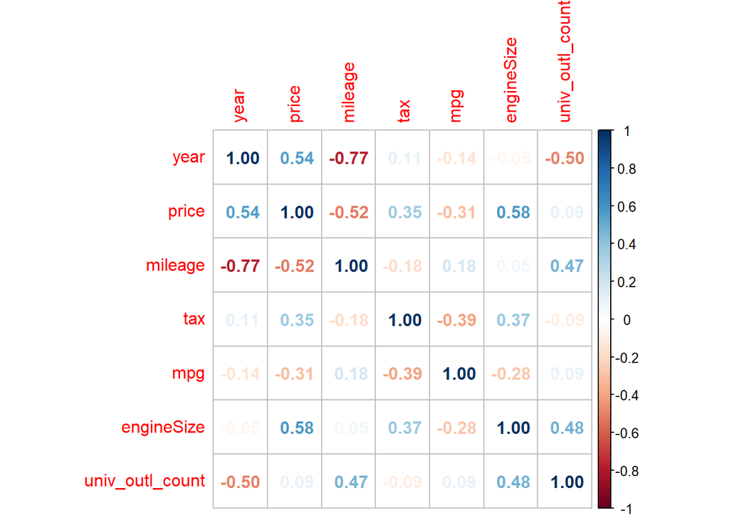

```r
df_of_interest = df[,c(2,3,5,7,8,9,18)]
cor_outl = cor(df_of_interest)
require(corrplot)
par(mfrow=c(1,1))
corrplot(cor_outl, method = 'number')
```

### Multivariate Outliers

Moutlier is applied on the numerical variables to find multivariate outliers. With the tax variable included, however, the method returns a singular matrix. Therefore this variable is excluded from the calculation. A very mild threshold of 0.5 % is chosen as signficance level because is already returns a significant amount of outliers; This makes up around 4% of the total amount of instances. It is chosen to delete these outliers from the data set for the rest of the project.

```r
require(chemometrics)
res.out = Moutlier(df[,c(2,3,5,8,9)], quantile = 0.995, col="green")
```

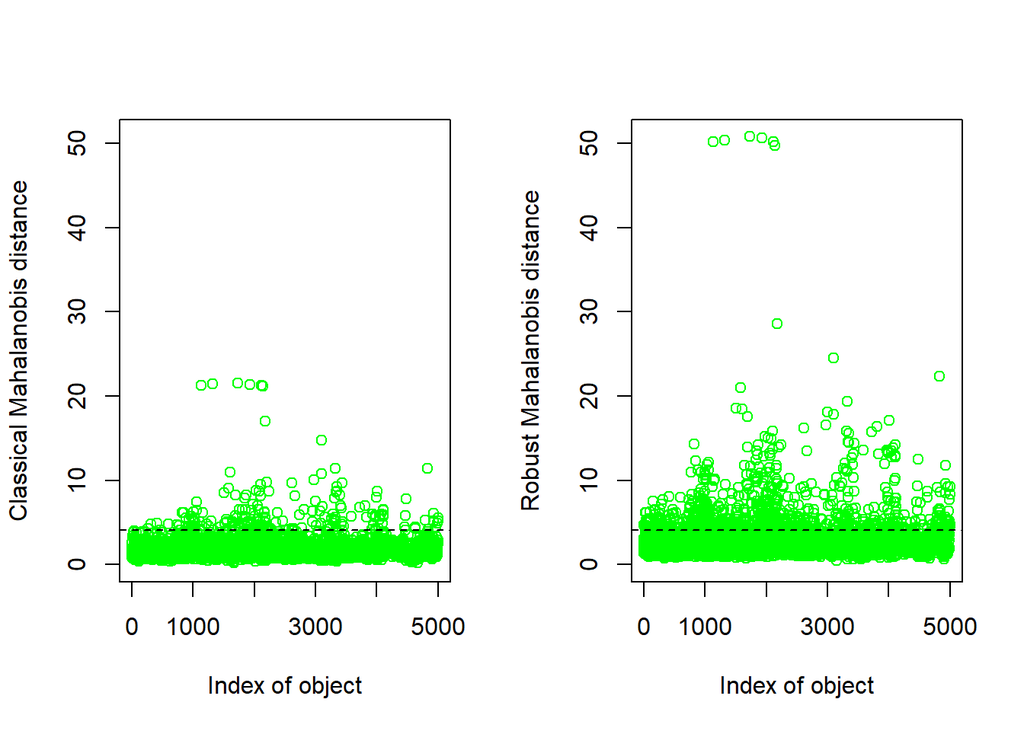

```r
which(res.out$md > res.out$cutoff)
```

```
##   [1]  268  306  409  603  740  776  825  848  888  897  928  929  969  976  979
##  [16]  992  997 1000 1004 1005 1007 1014 1023 1032 1038 1058 1061 1108 1122 1133
##  [31] 1141 1154 1217 1258 1299 1324 1445 1508 1523 1543 1549 1554 1582 1609 1638
##  [46] 1640 1642 1648 1683 1684 1687 1689 1697 1714 1732 1741 1749 1750 1768 1806
##  [61] 1811 1835 1837 1839 1845 1846 1847 1850 1853 1861 1881 1892 1906 1934 1939
##  [76] 1954 1956 1981 1986 1993 2009 2010 2029 2035 2045 2048 2049 2058 2068 2078
##  [91] 2082 2088 2096 2103 2104 2105 2106 2114 2130 2138 2167 2169 2172 2173 2180
## [106] 2181 2182 2191 2198 2233 2240 2262 2276 2352 2373 2467 2510 2562 2609 2611
## [121] 2633 2649 2659 2744 2771 2812 2944 2952 2972 2995 3013 3077 3087 3100 3103
## [136] 3111 3148 3198 3204 3213 3238 3265 3284 3296 3311 3325 3328 3329 3331 3332
## [151] 3341 3343 3344 3401 3412 3417 3425 3430 3431 3466 3578 3722 3811 3831 3926
## [166] 3929 3947 3971 3978 3982 3995 4011 4034 4046 4048 4064 4100 4101 4107 4109
## [181] 4110 4113 4456 4462 4479 4628 4633 4794 4827 4842 4922 4924 4929 4966 4995
## [196] 4998 5000
```

```r
length(which(res.out$md > res.out$cutoff))/5000
```

```
## [1] 0.0394
```

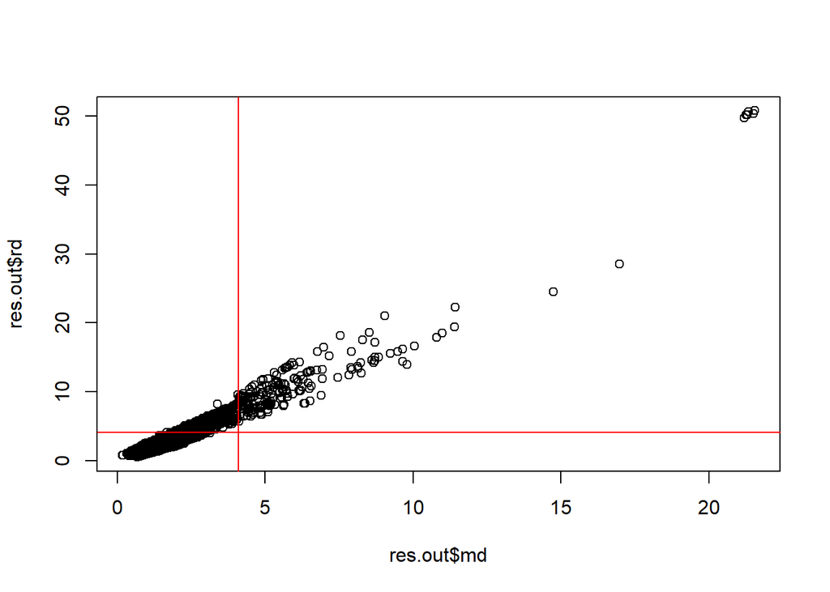

```r
par(mfrow=c(1,1))
plot( res.out$md, res.out$rd )
abline(h=res.out$cutoff, col="red")
abline(v=res.out$cutoff, col="red")
```

```r
summary(df[which(res.out$md > res.out$cutoff),])
```

```
##     model                year          price           transmission
##  Length:197         Min.   :2000   Min.   :  1275   Automatic:97
##  Class :character   1st Qu.:2010   1st Qu.:  7000   Manual   :53
##  Mode  :character   Median :2016   Median : 17950   Semi-Auto:47
##                     Mean   :2014   Mean   : 28136
##                     3rd Qu.:2017   3rd Qu.: 44450
##                     Max.   :2020   Max.   :149948
##     mileage         fuelType       tax             mpg          engineSize
##  Min.   :    16   Diesel:68   Min.   :  0.0   Min.   : 19.5   Min.   :0.000
##  1st Qu.:  9377   Other :50   1st Qu.:125.0   1st Qu.: 31.0   1st Qu.:2.000
##  Median : 43000   Petrol:79   Median :145.0   Median : 45.6   Median :2.000
##  Mean   : 57579               Mean   :176.3   Mean   : 77.8   Mean   :2.524
##  3rd Qu.: 99217               3rd Qu.:260.0   3rd Qu.:117.7   3rd Qu.:3.000
##  Max.   :212000               Max.   :570.0   Max.   :470.8   Max.   :6.200
##    manufacturer     n.age               f.age            f.price
##  Audi    :27    Min.   : 0.000   LowAge    :38   LowPrice    :86
##  BMW     :75    1st Qu.: 3.000   LowMidAge :42   LowMidPrice :27
##  Mercedes:58    Median : 4.000   HighMidAge:26   HighMidPrice:21
##  VW      :37    Mean   : 6.061   HighAge   :91   HighPrice   :63
##                 3rd Qu.:10.000
##                 Max.   :20.000
##           f.mileage          f.tax           f.mpg               f.engineSize
##  LowMileage    : 36   Lowtax    :53   Lowmpg    :96   LowengineSize    :32
##  LowMidMileage : 22   LowMidtax :25   LowMidmpg :15   LowMidengineSize :11
##  HighMidMileage: 28   HighMidtax:44   HighMidmpg:19   HighMidengineSize:69
##  HighMileage   :111   Hightax   :75   Highmpg   :67   HighengineSize   :85
##
##
##  univ_outl_count
##  Min.   :0.000
##  1st Qu.:2.000
##  Median :2.000
##  Mean   :2.107
##  3rd Qu.:3.000
##  Max.   :4.000
```

```r
summary(df)
```

```
##     model                year          price           transmission
##  Length:5000        Min.   :2000   Min.   :  1275   Automatic:1317
##  Class :character   1st Qu.:2016   1st Qu.: 14000   Manual   :1775
##  Mode  :character   Median :2017   Median : 19799   Semi-Auto:1908
##                     Mean   :2017   Mean   : 21602
##                     3rd Qu.:2019   3rd Qu.: 26000
##                     Max.   :2020   Max.   :149948
##     mileage         fuelType         tax             mpg
##  Min.   :     1   Diesel:2774   Min.   :  0.0   Min.   : 19.50
##  1st Qu.:  5728   Other :  80   1st Qu.:125.0   1st Qu.: 44.10
##  Median : 16395   Petrol:2146   Median :145.0   Median : 52.80
##  Mean   : 23042                 Mean   :124.9   Mean   : 53.96
##  3rd Qu.: 33102                 3rd Qu.:145.0   3rd Qu.: 61.40
##  Max.   :212000                 Max.   :570.0   Max.   :470.80
##    engineSize      manufacturer      n.age               f.age
##  Min.   :0.000   Audi    :1075   Min.   : 0.000   LowAge    :1938
##  1st Qu.:1.500   BMW     :1096   1st Qu.: 1.000   LowMidAge :1426
##  Median :2.000   Mercedes:1308   Median : 3.000   HighMidAge: 798
##  Mean   :1.922   VW      :1521   Mean   : 2.788   HighAge   : 838
##  3rd Qu.:2.000                   3rd Qu.: 4.000
##  Max.   :6.200                   Max.   :20.000
##          f.price              f.mileage           f.tax             f.mpg
##  LowPrice    :1257   LowMileage    :1250   Lowtax    :1349   Lowmpg    :1257
##  LowMidPrice :1244   LowMidMileage :1250   LowMidtax :  34   LowMidmpg :1243
##  HighMidPrice:1258   HighMidMileage:1250   HighMidtax:2610   HighMidmpg:1342
##  HighPrice   :1241   HighMileage   :1250   Hightax   :1007   Highmpg   :1158
##
##
##             f.engineSize  univ_outl_count
##  LowengineSize    :1496   Min.   :0.0000
##  LowMidengineSize : 332   1st Qu.:0.0000
##  HighMidengineSize:2104   Median :0.0000
##  HighengineSize   :1068   Mean   :0.5234
##                           3rd Qu.:1.0000
##                           Max.   :4.0000
```

```r
df = df[-which(res.out$md > res.out$cutoff),]
```

# Profiling

## Determine if the response variable (price) has an acceptably normal distribution. Address test to discard serial correlation.

To test for autocorrelation the acf() function is used, of which the result can be seen below.

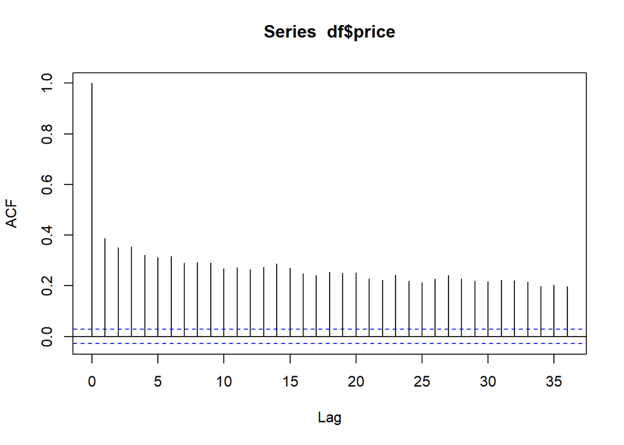

```r
acf(df$price)
```

```r
shapiro.test(df$price)
```

```
##
##  Shapiro-Wilk normality test
##
## data:  df$price
## W = 0.93366, p-value < 2.2e-16
```

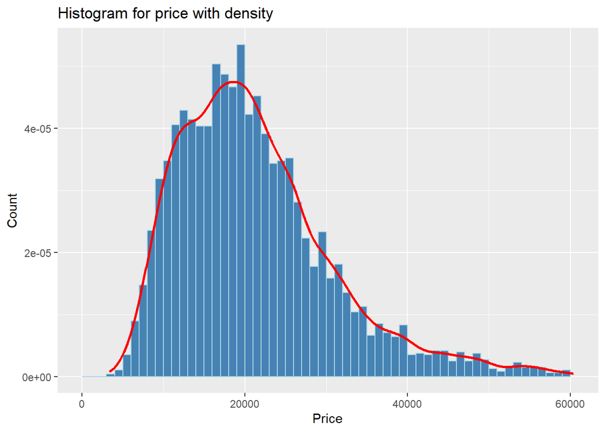

```r
ggplot(data=df, aes(price, y = ..density..)) +
  geom_histogram(breaks=seq(0, max(df$price), by=1000),
                 col='lightblue',
                 fill='steelblue') +
  geom_density(lwd=1,
               col='red') +
  labs(title="Histogram for price with density", x="Price", y="Count")
```

## Indicate by exploration of the data which are apparently the variables most associated with the response variable (use only the indicated variables).

To do this, the condes function of the FactoMiner package is used, which for the numeric response variable ‘price’ calculates the correlation of each of the quantitative variables and the coefficient of determination (R^2) for the qualitative variables, together with a p-value for significance.

For the quantitative variables it is clear both engineSize and year are highly significant positively correlated (r > 0.50, p = 0) to the price. This seems logical as the higher the newer the car is and the bigger the engine, the more it would cost. The mileage and miles per gallon (mpg) are highly significant negatively correlated to the price (r < -0.50 p = 0) which also to be expected: the more a car has driven, the less its value and small motors are more efficient (lower mpg). Tax has a less but also significant positive correlation to the price (r = 0.44, p ~ 0), which makes sense semantically again. To further illustrate the correlations, a correlation matrix is plotted as well.

```r
require(FactoMineR)
```

```r
require(corrplot)

res.con = condes(df,3)
res.con$quanti
```

```
##                 correlation       p.value
## year             0.61625532  0.000000e+00
## engineSize       0.57896627  0.000000e+00
## tax              0.43982997 1.929722e-226
## univ_outl_count  0.06151968  1.985884e-05
## mileage         -0.55367677  0.000000e+00
## mpg             -0.60490687  0.000000e+00
## n.age           -0.61625532  0.000000e+00
```

```r
res.con$quali
```

```
##                       R2       p.value
## model        0.487739508  0.000000e+00
## f.age        0.381784788  0.000000e+00
## f.price      0.813844246  0.000000e+00
## f.mileage    0.337295393  0.000000e+00
## f.tax        0.276519319  0.000000e+00
## f.mpg        0.355074061  0.000000e+00
## transmission 0.248188295 4.589851e-298
## f.engineSize 0.226876560 1.878794e-267
## manufacturer 0.094372257 8.545144e-103
## fuelType     0.008387365  1.663122e-09
```

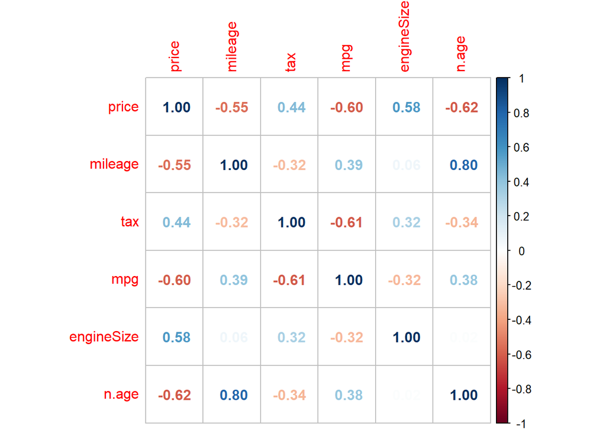

```r
df_num = df[,c(3,5,7,8,9,11)]
cor_num = cor(df_num)
corrplot(cor_num, method = 'number')
```